# AoU Observational Results

# Examining Observational/EHR Associations between Loneliness and Psychiatric and Immune Conditions

## UCLA Loneliness Cohort Description and Sample Sizes

- N UCLA Loneliness Scale = 290,522

### N Immune Biomarker Measures with UCLA Loneliness:

| Immune Biomarker | N (within 1 year of UCLA Loneliness) |
| --- | --- |
| CRP | 16,466 |
| Albumin | 81,207 |
| Basophils | 43,382 |
| Eosinophils | 46,606 |
| Leukocytes | 75,849 |
| Monocytes | 45,451 |
| Neutrophils | 42,559 |
| Platelets | 80,823 |
| Triglycerides | 89,235 |

### N Psychiatric Condition Diagnoses (consistent on at least 2 occasions) with UCLA Loneliness:

| Psychiatric Diagnosis (at least 2 separate classifications) | N (with UCLA Loneliness) |
| --- | --- |
| Anxiety | 56,679 |
| Depression | 52,388 |
| PTSD | 9,922 |
| ADHD | 8,756 |
| Bipolar Disorder | 6,691 |
| Personality Disorder | 2,646 |
| Eating Disorder | 2,488 |
| OCD | 1,317 |
| Schizophrenia | 683 |
| Autism | 620 |

### N Immune Condition Diagnoses with UCLA Loneliness:

| Immune Condition | N |
| --- | --- |
| Asthma | 32,055 |
| Allergic Rhinitis | 42,911 |
| Rheumatoid Arthritis | 5,420 |
| Hypothyroidism | 30,177 |
| Ulcerative Colitis | 2,198 |
| Type II Diabetes | 29,183 |
| Crohn’s Disease | 2,111 |
| Atopic Dermatitis | 5,815 |

### Demographic Covariates and Loneliness

- higher loneliness among females than males

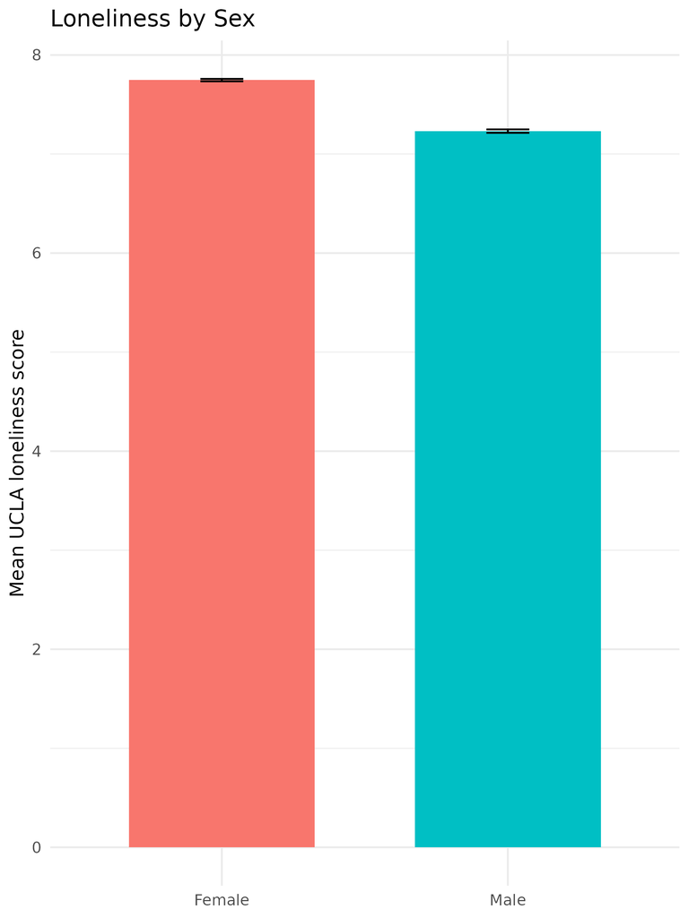

Loneliness by Sex

- loneliness decreases as income increases

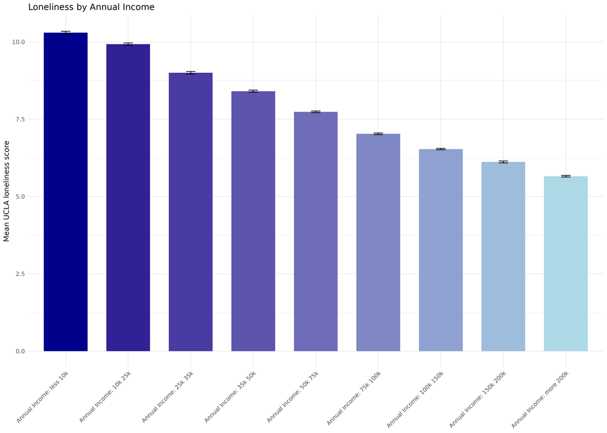

## Loneliness and Psychiatric Diagnoses

- higher loneliness among individuals with any of these 10 diagnoses

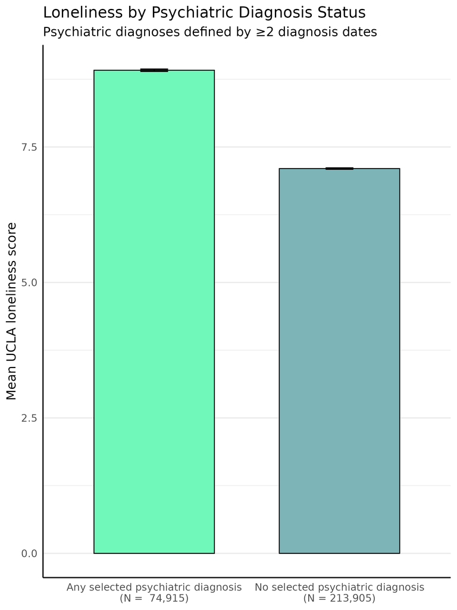

Loneliness Psych Diagnosis vs None

- highest loneliness among individuals with autism and personality disorder

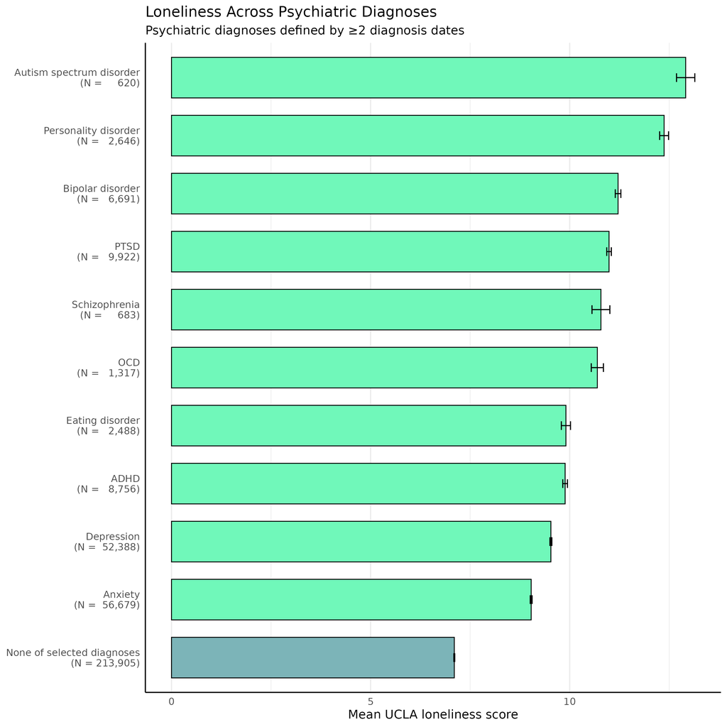

Loneliness Across Psych Diagnoses

- loneliness (adjusting for covariates: race, sex, education, income, age, bmi) increases OR of psychiatric conditions

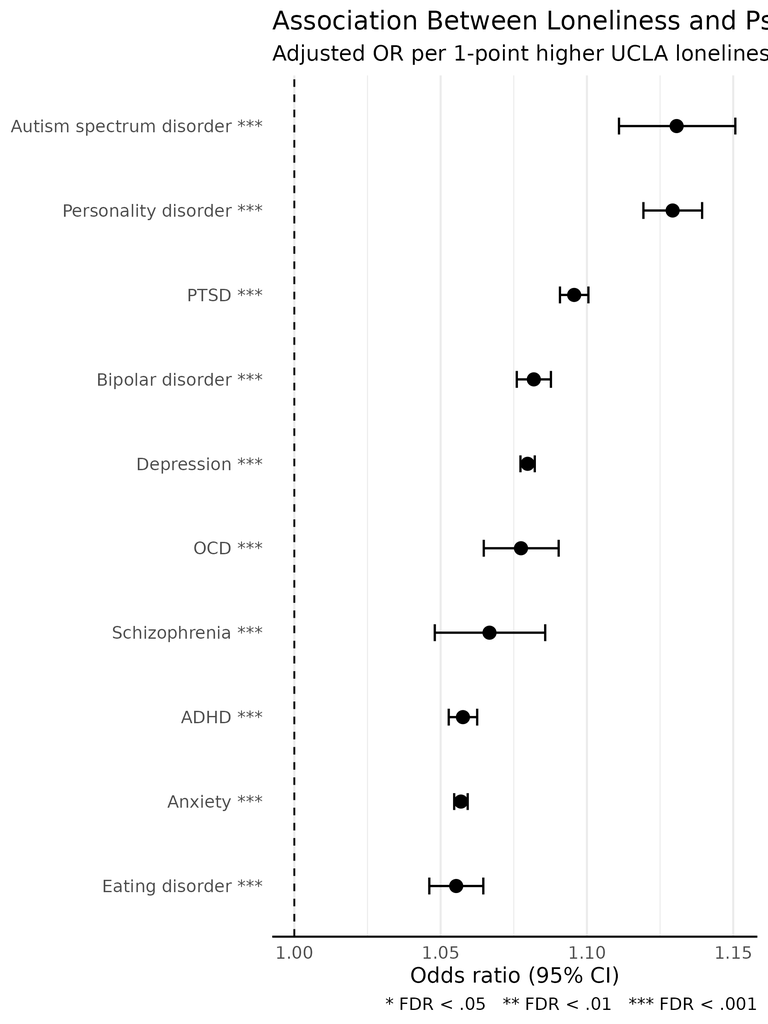

Loneliness Psychiatric OR

### Loneliness and Immune Conditions

- statistically detectable but clinically not meaningful difference between individuals with immune condition diagnosis vs without

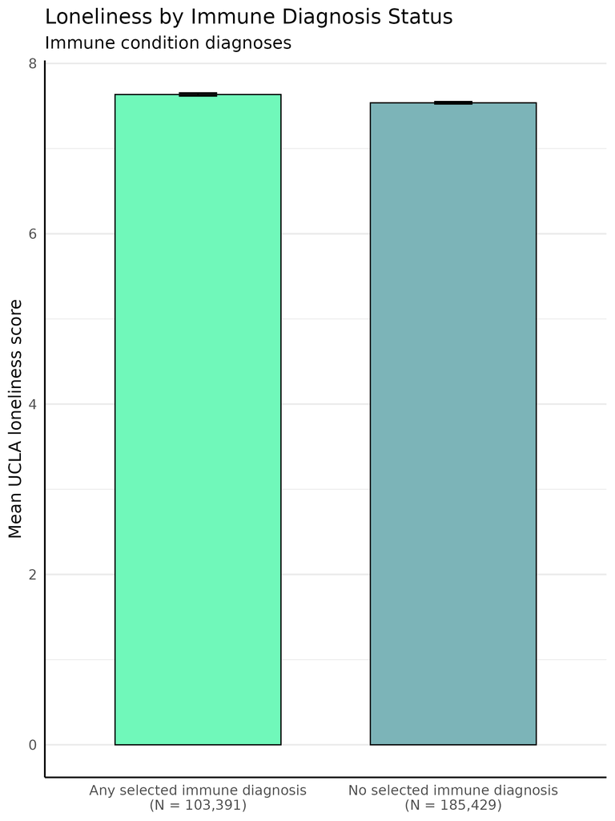

Loneliness by Immune Condition

- loneliness increase OR of rheumatoid arthritis and other conditions adjusting for covariates + bmi

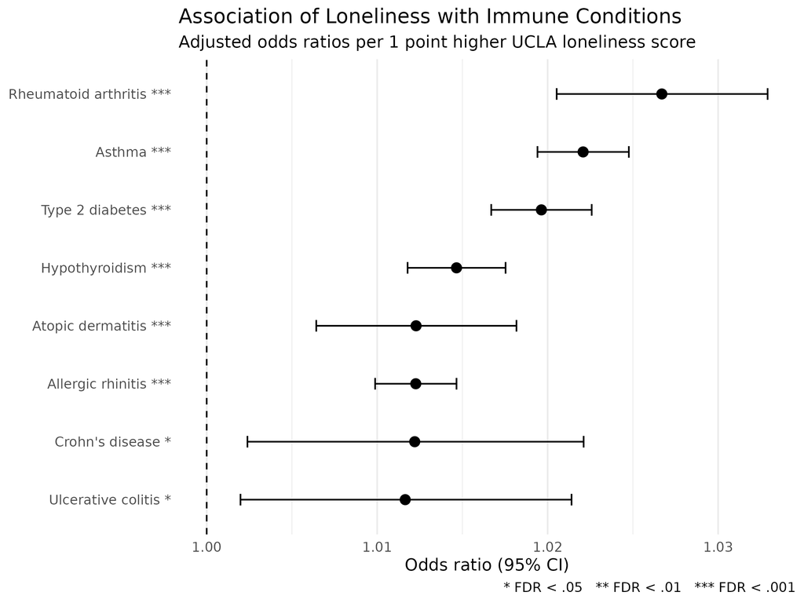

Loneliness Immune Condition OR

### Loneliness and Immune Biomarkers

- statistically detectable but small effects of loneliness on immune biomarker counts

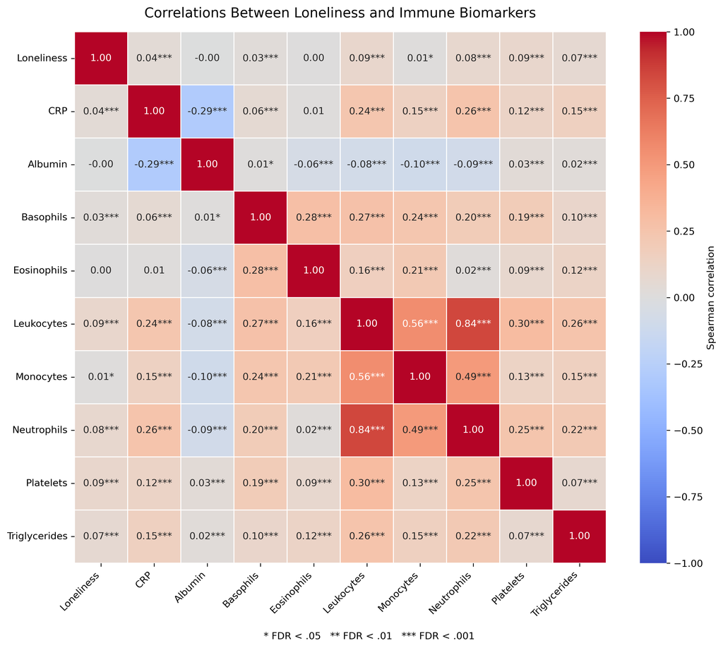

Loneliness Immune Biomarker Correlation Heatmap

- loneliness associated with increased counts of specific biomarkers, adjusting for covariates (also replicated using log-transformed values)
- adjusting for BMI, only neutrophils becomes no longer significant, but the others are attenuated down

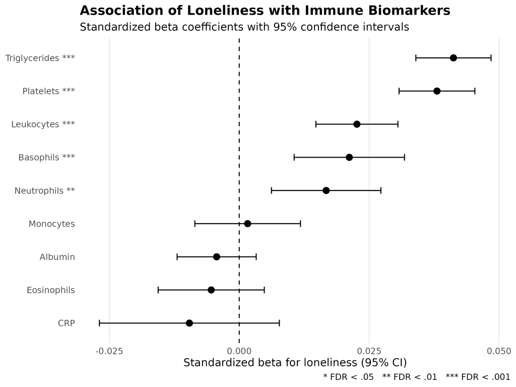

Loneliness Immune Biomarker Forest

## Loneliness, Income x Sex Interacions in Biomarker Levels

- For platelets, significant main effects of loneliness, sex and income, but no interactions
- Main effect of income on all biomarkers
- Main effect of sex on all biomarkers (but weak for neutrophils)
- Main effect of loneliness on all biomarkers except Albumin (males only)
- Sex x Income interaction for Basophils, CRP, Eosinophils, Monocytes & Triglycerides
- Sex x Loneliness interaction for Albumin, Leukocytes, Monocytes, Neutrophils & Triglycerides
- No sig. Loneliness x Income interactions
- Plotting Estimated Marginal means from interaction models

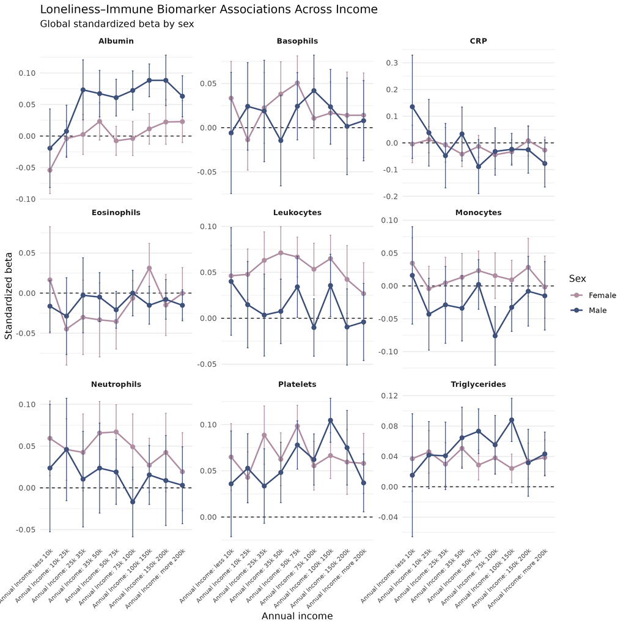

Associations between loneliness and biomarker across income levels

### Albumin

- Loneliness associated with albumin levels only among males, not females
- Significant loneliness x male sex interaction (b = 0.063, p < 0.0001)

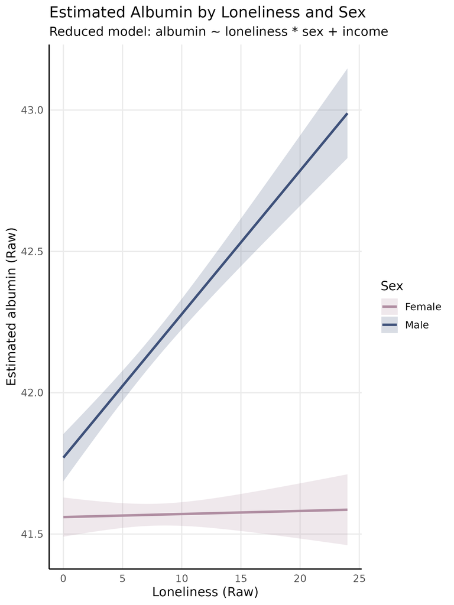

Association between loneliness and albumin levels among males vs females

### Basophils

- Loneliness associated with increased basophil levels.
- Male sex associated with higher basophil levels than females, but sex-specific differences reduce as income increases.
- Significant income x male sex interaction (b = -0.013, p = 0.008)

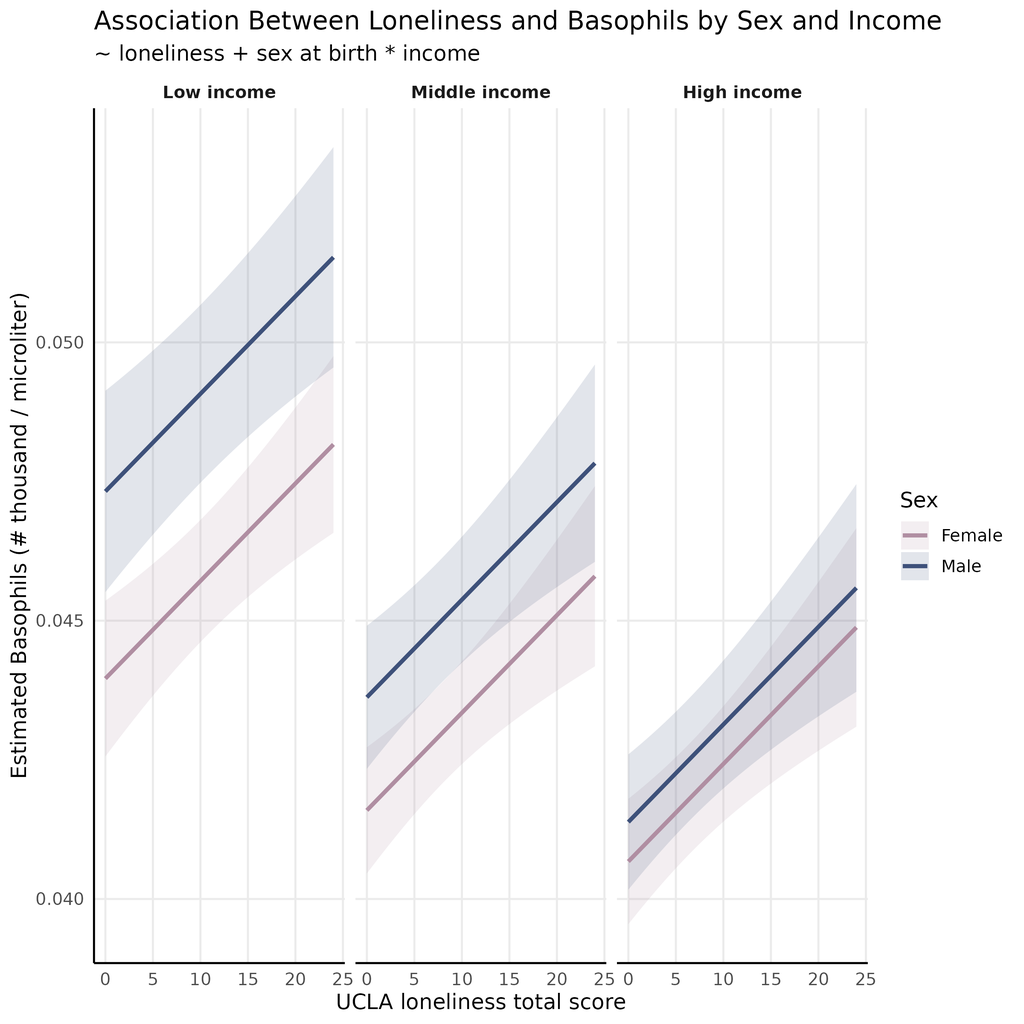

Sex-differences basophils reduce with increased income

### CRP

- Loneliness associated with reduced CRP levels.
- But this pattern is reversed among low income males (relative to high income males, and females)
- Significant income x male sex interaction (b = -0.038, p < 0.001)

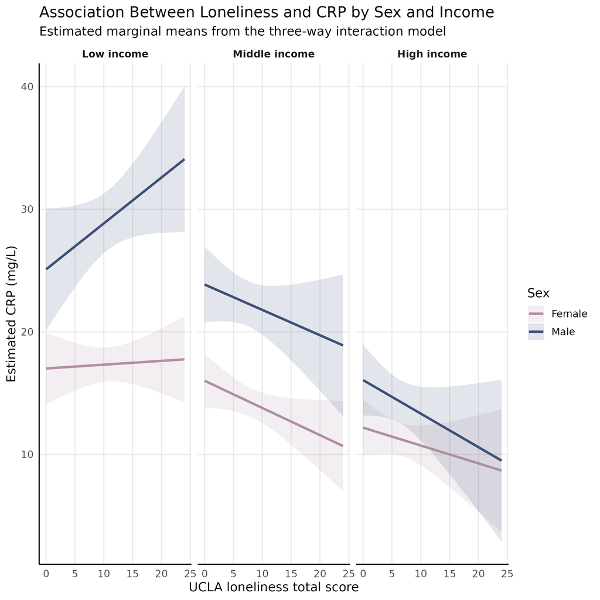

Reversed effect of loneliness on CRP among low income males

### Eosinophils

- Loneliness associated with reduced eosinophils
- Significant main effect of income on eosinophil level (b = -0.022, p < 0.001)

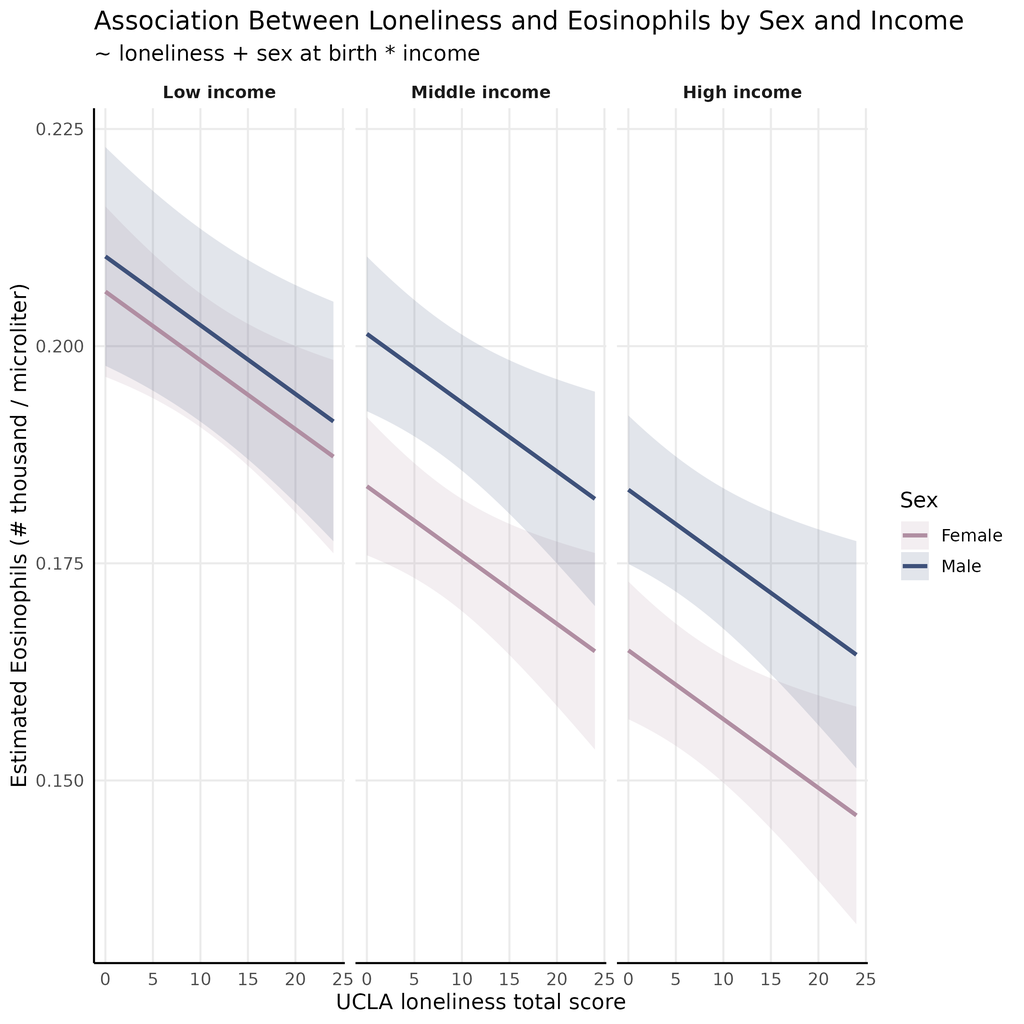

Loneliness reduces eosinophil

### Leukocytes and Neutrophils

- Loneliness associated with increased leukocytes and neutrophils
- Significant loneliness x male sex interaction for leukocytes (b = -0.040, p < 0.001) and neutrophils (b = -0.029, p = 0.005)

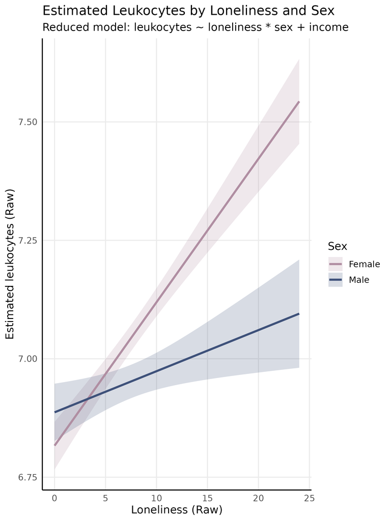

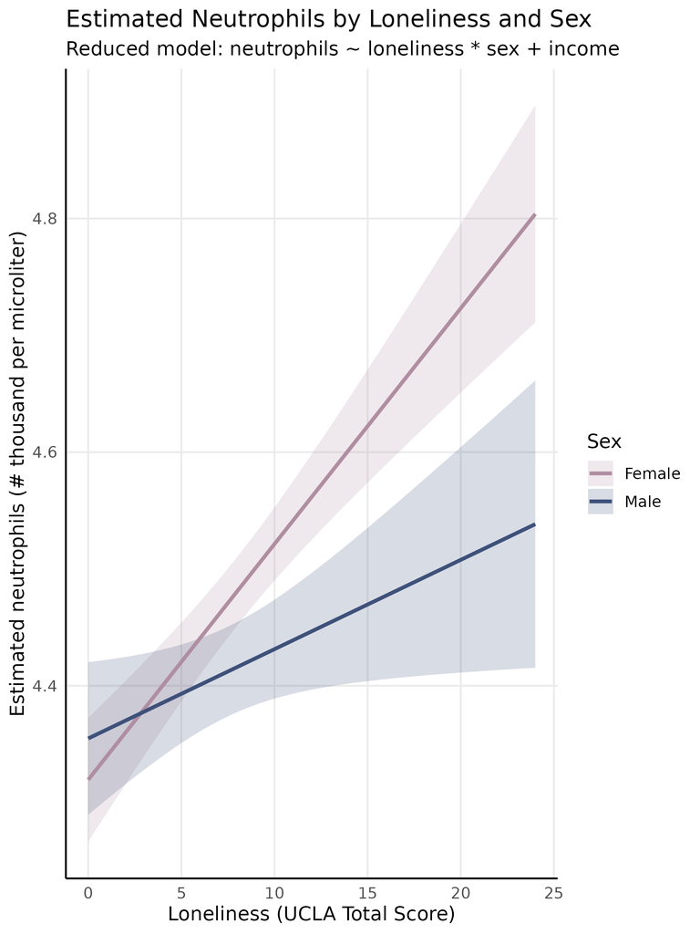